Ana Paola Loredo Moreno 613772

Doy mi palabra que he realizado esta actividad con integridad académica.

# Introducción

La seguridad social es un derecho humano que garantiza acceso a salud, asistencia médica y servicios social. La seguridad social es un derecho humano pero desafortunadamente es un derecho humano que hoy en día se tiene que comprar. El objetivo de este reporte es determinar las probabilidades de que una persona cuente con seguro social dado sus características sociodemográficas y nivel de ingresos. En este reporte se entrenará un modelo de regresión logística utilizando los datos de la Encuesta Nacional de Ingresos y Gastos de los Hogares del 2022, diviendo los datos entre entrenamiento y prueba. La base de datos será dividida en conjuntos de entrenamiento y prueba con el fin de evaluar el desempeño predictivo del modelo. A lo largo del reporte se presentará el proceso de construcción del modelo, así como su evaluación mediante métricas de clasificación, matrices de confusión y análisis de desempeño. Finalmente, se interpretarán los coeficientes obtenidos para comprender cómo cada variable influye en la probabilidad de acceso a la seguridad social.

#### Preparación de datos

```python
import pandas as pd
import numpy as np
import matplotlib.pyplot as plt

import pandas as pd
```

```python
## CODIGO GENERADO CON APOYO DE IA GENERATIVA

import pandas as pd
import numpy as np

# ============================================================
# 1️⃣ LEER INGRESOS (archivo ingresos.csv)
# ============================================================

print("Leyendo ingresos...")

ingresos = pd.read_csv(
    "ingresos.csv",
    usecols=['folioviv','foliohog','numren','ing_tri'],
    low_memory=False
)

# Convertir ingreso a número
ingresos['ing_tri'] = pd.to_numeric(ingresos['ing_tri'], errors='coerce')

# Quitar valores inválidos
ingresos = ingresos.dropna(subset=['ing_tri'])
ingresos = ingresos[ingresos['ing_tri'].notna()]

print("Filas de ingresos válidos:", ingresos.shape)


# ============================================================
# 2️⃣ COLAPSAR INGRESOS A NIVEL PERSONA
# (aquí ocurre la magia real de ENIGH)
# ============================================================

print("Agrupando ingresos por persona...")

ingresos_persona = (
    ingresos
    .groupby(['folioviv','foliohog','numren'], as_index=False)
    .agg(ingreso_total=('ing_tri','sum'))
)

print("Personas con ingreso:", ingresos_persona.shape)


# ============================================================
# 3️⃣ LEER POBLACIÓN
# ============================================================


import pandas as pd

print("Leyendo población...")

cols_disc = [
    "disc_camin","disc_ver","disc_brazo","disc_apren",
    "disc_oir","disc_vest","disc_habla","disc_acti"
]

poblacion = pd.read_csv(
    "poblacion.csv",
    usecols=[
       'folioviv','asis_esc','trabajo_mp','parentesco','foliohog','trabajo_mp','numren','edad','sexo','nivelaprob','gradoaprob','alfabetism','edo_conyug','hijos_viv','diabetes','pres_alta','segsoc','pop_insabi','entidad',*cols_disc
    ],
    low_memory=False
)

print("Personas en población:", poblacion.shape)

poblacion[cols_disc] = poblacion[cols_disc].replace(5, pd.NA)

# Asegurar que sean numéricas
poblacion[cols_disc] = poblacion[cols_disc].apply(pd.to_numeric, errors='coerce')

# Discapacidad = tener al menos UNA dificultad (niveles 2,3 o 4)
poblacion["Discapacidad"] = poblacion[cols_disc].apply(
    lambda row: row.isin([2, 3]).any(),
    axis=1
).astype(int)

##print("\nDistribución real de discapacidad:")
##print(poblacion["Discapacidad"].value_counts())

##print("\nEjemplo de frecuencias por variable:")
##for c in cols_disc:
 ##   print("\n", c)
  ##  print(poblacion[c].value_counts(dropna=False))

# ============================================================
# 4️⃣ FILTRAR EDAD LABORAL
# ============================================================

poblacion = poblacion[(poblacion['edad'] >= 18) & (poblacion['edad'] <= 65)]

print("Personas 18–65:", poblacion.shape)


# ============================================================
# 6️⃣ NOS QUEDAMOS SOLO CON VARIABLES NECESARIAS
# ============================================================

poblacion = poblacion[
    [
       'folioviv','asis_esc','parentesco','foliohog','trabajo_mp','numren','edad','sexo','nivelaprob','gradoaprob','alfabetism','edo_conyug','hijos_viv','diabetes','pres_alta','segsoc','pop_insabi','entidad','Discapacidad'
    ]
]

# ============================================================
# 7️⃣ MERGE CORRECTO (AHORA SÍ 1 A 1 REAL)
# ============================================================

print("Uniendo población con ingresos...")

df_final = poblacion.merge(
    ingresos_persona,
    on=['folioviv','foliohog','numren'],
    how='left'
)

df_final['ingreso_total'] = df_final['ingreso_total'].fillna(0)


print("Base final:", df_final.shape)


# ============================================================
# 8️⃣ TRANSFORMACIÓN PARA REGRESIÓN
# ============================================================

df_modelo = df_final.copy()

df_modelo['log_ingreso'] = np.log1p(df_modelo['ingreso_total'])

# Experiencia potencial tipo Mincer
df_modelo['edad2'] = df_modelo['edad']**2

df_modelo = pd.get_dummies(
    df_modelo,
    columns=[
        'edo_conyug','segsoc','entidad'
    ],
    drop_first=True
)

# ============================================================
# 9️⃣ GUARDAR BASE FINAL
# ============================================================

print("Archivo creado: base_enigh_modelo.csv")
```

```
Leyendo ingresos...
Filas de ingresos válidos: (397182, 4)
Agrupando ingresos por persona...
Personas con ingreso: (205144, 4)
Leyendo población...
Personas en población: (309684, 26)
Personas 18–65: (190245, 27)
Uniendo población con ingresos...
Base final: (190245, 20)
Archivo creado: base_enigh_modelo.csv
```

### Variables seleccionadas de los conjuntos de datos:

A pesar de aún no modelar el modelo, para no hacer uso excesivo a la memoria RAM y tener una vista más clara del modelo, desde un inicio se hizo la mayoría de trabajo de selección de datos del modelo. En lugar de cargar 188 variables del archivo poblacion.csv, se utilizó el parámetro usecols de pandas para importar únicamente las columnas relevantes para el modelo.

#### Identificadores:

- folioviv — folio de la vivienda, identifica el hogar
- foliohog — folio del hogar dentro de la vivienda

#### Variables demográficas:

- edad — edad en años cumplidos
- sexo — 1=hombre, 2=mujer
- entidad — clave INEGI del estado (1=Aguascalientes ... 32=Zacatecas)
- edo_conyug — estado conyugal: 1=casado, 2=unión libre, 3=separado, 4=divorciado, 5=viudo, 6=soltero

#### Capital:

- nivelaprob — nivel educativo aprobado (0=ninguno, 1=preescolar... 8=posgrado)
- gradoaprob — grado aprobado dentro del nivel (0-6)
- alfabetism — 1=sabe leer y escribir, 2=no sabe
- trabajo_mp - mide si la persona trabajo la semana pasada o no
- asis_esc - si la persona asiste actualmente a la escuela

#### Familia:

- hijos_viv — número de hijos vivos

#### Salud:

- diabetes — 1=tiene diabetes, 2=no
- pres_alta — 1=tiene presión alta, 2=no
- Discapacidad — variable construida por ti: 1=tiene alguna limitación funcional, 0=no

#### Laboral/económico:

- segsoc — 1 = tiene acceso a seguridad social, 1= si, 2=no
- pop_insabi — 1=afiliado al INSABI, 2=no
- ingreso_total — ingreso trimestral total en pesos, construido sumando todas las fuentes de ingresos.csv

```python
df_final.info()
```

```
<class 'pandas.DataFrame'>
RangeIndex: 190245 entries, 0 to 190244
Data columns (total 20 columns):
 #   Column         Non-Null Count   Dtype
---  ------         --------------   -----
 0   folioviv       190245 non-null  int64
 1   asis_esc       190245 non-null  str
 2   parentesco     190245 non-null  int64
 3   foliohog       190245 non-null  int64
 4   trabajo_mp     190245 non-null  str
 5   numren         190245 non-null  int64
 6   edad           190245 non-null  int64
 7   sexo           190245 non-null  int64
 8   nivelaprob     190245 non-null  str
 9   gradoaprob     190245 non-null  str
 10  alfabetism     190245 non-null  str
 11  edo_conyug     190245 non-null  str
 12  hijos_viv      190245 non-null  str
 13  diabetes       190245 non-null  str
 14  pres_alta      190245 non-null  str
 15  segsoc         190245 non-null  str
 16  pop_insabi     190245 non-null  str
 17  entidad        190245 non-null  int64
 18  Discapacidad   190245 non-null  int64
 19  ingreso_total  190245 non-null  float64
dtypes: float64(1), int64(8), str(11)
memory usage: 29.0 MB
```

#### Transformación de variables nominables y de tipo 'string'

```python
df.describe(include='object')

cols = ['nivelaprob','gradoaprob','hijos_viv','diabetes','pres_alta','segsoc','pop_insabi','alfabetism','asis_esc','trabajo_mp','edo_conyug']

for c in cols:
    print(f"\n===== {c} =====")
    print(df_final[c].unique())
```

```
===== nivelaprob =====
<StringArray>
['4', '7', '3', '5', '8', '6', '2', '0', '9', '1']
Length: 10, dtype: str

===== gradoaprob =====
<StringArray>
['3', '5', '4', '2', '6', '1', '0']
Length: 7, dtype: str

===== hijos_viv =====
<StringArray>
[ '1',  '2',  ' ',  '0',  '4',  '3',  '5',  '6',  '7',  '9',  '8', '10', '11',
 '14', '12', '13', '17', '15', '16']
Length: 19, dtype: str

===== diabetes =====
<StringArray>
['2', '1', ' ']
Length: 3, dtype: str

===== pres_alta =====
<StringArray>
['1', '2', ' ']
Length: 3, dtype: str

===== segsoc =====
<StringArray>
['2', '1', ' ']
Length: 3, dtype: str

===== pop_insabi =====
<StringArray>
['2', '1', ' ']
Length: 3, dtype: str

===== alfabetism =====
<StringArray>
['1', '2']
Length: 2, dtype: str

===== asis_esc =====
<StringArray>
['2', '1']
Length: 2, dtype: str

===== trabajo_mp =====
<StringArray>
['1', '2', ' ']
Length: 3, dtype: str

===== edo_conyug =====
<StringArray>
['6', '2', '1', '5', '4', '3']
Length: 6, dtype: str
```

```python
cols_str = [
    'nivelaprob','gradoaprob','hijos_viv',
    'diabetes','pres_alta','segsoc','pop_insabi','alfabetism','asis_esc'
]

df_final[cols_str] = df_final[cols_str].replace(r'^\s*$', np.nan, regex=True)

for c in cols_str:
    df_final[c] = pd.to_numeric(df_final[c], errors='coerce')

df_final['hijos_viv'] = df_final['hijos_viv'].fillna(0)


df_final['diabetes']   = (df_final['diabetes'] == 1).astype(int)
df_final['pres_alta']  = (df_final['pres_alta'] == 1).astype(int)


df_final['segsoc'] = (df_final['segsoc'] == 1).astype(int)

df_final['pop_insabi'] = (df_final['pop_insabi'] == 1).astype(int)

df_final['nivelaprob'] = df_final['nivelaprob'].fillna(0)
df_final['gradoaprob'] = df_final['gradoaprob'].fillna(0)

df_final['nivelaprob'] = df_final['nivelaprob'].fillna(0)
df_final['gradoaprob'] = df_final['gradoaprob'].fillna(0)

### transformación de nivelaprob y gradoaprob
df_final['educacion_total'] = df_final['nivelaprob'] * 3 + df_final['gradoaprob']

df_final['alfabetism'] = df_final['alfabetism'].replace(' ', np.nan)
df_final['alfabetism'] = pd.to_numeric(df_final['alfabetism'], errors='coerce')

# Crear variable binaria interpretable
df_final['alfabetizado'] = (df_final['alfabetism'] == 1).astype(int)

df_final['edo_conyug'] = df_final['edo_conyug'].replace(' ', np.nan)
df_final['edo_conyug'] = pd.to_numeric(df_final['edo_conyug'], errors='coerce')

df_final = pd.get_dummies(
    df_final,
    columns=['edo_conyug'],
    prefix='conyug',
    drop_first=True
)

df_final['asis_esc'] = df_final['asis_esc'].replace(' ', np.nan)
df_final['asis_esc'] = pd.to_numeric(df_final['asis_esc'], errors='coerce')
df_final['asis_esc'] = df_final['asis_esc'].map({1:1, 2:0})

df_final['trabajo_mp'] = df_final['trabajo_mp'].replace(' ', np.nan)
df_final['trabajo_mp'] = pd.to_numeric(df_final['trabajo_mp'], errors='coerce')
df_final['trabajo_mp'] = df_final['trabajo_mp'].map({1:1, 2:0})
```

#### Conjunto de datos listo para utilizar

```python
df_final.info()
```

[output not shown]

[output cut: 18 more lines]

### Balance de clases

Para un modelo de regresión logística, la variable de interés debe ser categorica para obtener la probabilidad de distintos escenarios. En este caso existen dos escenarios a analizar, la probabilidad de tener seguro y la probabilidad de no tener seguro. Para entrenar un modelo eficiente y equitativo para ambas clases a analizar. En caso de que una clase obtenga la mayoría de datos, el modelo se convertiría experto en predecir un resultado que desde un inicio estaba claro que siempre sería el mismo, obteniendo métricas de accuracy aparentemente altas pero sin capacidad real de discriminación. Para evitar sesgos del modelo, antes de construir el modelo probamos el balance de clases de nuestra variable de interés.

Los resultados muestran que la distribución es consistente en los tres conjuntos: la clase 0 (sin seguro) representa aproximadamente el 49% y la clase 1 aproximadamente el 51% en los tres subconjuntos. Esta consistencia confirma que la división 80/20 preservó correctamente las proporciones originales, lo cual es importante para que las métricas de evaluación en el conjunto de prueba sean representativas del comportamiento real del modelo.

[figure not shown]

```python
df_final["segsoc"].value_counts()

plt.figure(figsize=(6, 4))
sns.countplot(x=y, palette='Blues')
plt.title('Distribución de clases - segsoc')
plt.xlabel('Clase (0 = sin seguro, 1 = con seguro)')
plt.ylabel('Cantidad')
plt.xticks([0, 1], ['Sin seguro (0)', 'Con seguro (1)'])
for p in plt.gca().patches:
    plt.gca().annotate(f'{int(p.get_height()):,}',
                       (p.get_x() + p.get_width()/2, p.get_height()),
                       ha='center', va='bottom')
plt.tight_layout()
plt.show()
```

```
=== Proporción de clases ===
        Original  Train (80%)  Test (20%)
segsoc
0         0.4898       0.4896      0.4909
1         0.5102       0.5104      0.5091

=== Conteos absolutos ===
        Train (80%)  Test (20%)
segsoc
0             74460       18667
1             77632       19356
```

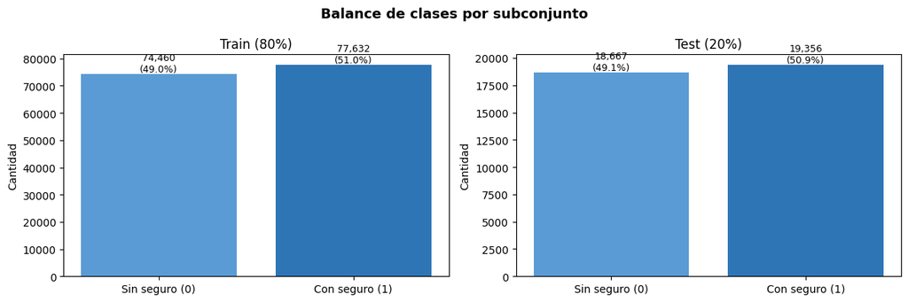

```python
import matplotlib.pyplot as plt
import numpy as np

def class_dist(data, label):
    counts = pd.Series(data).value_counts(normalize=True).sort_index()
    return counts

orig = class_dist(y, 'Original')
train = class_dist(y_train, 'Train')
test = class_dist(y_test, 'Test')

dist_df = pd.DataFrame({
    'Original': orig,
    'Train (80%)': train,
    'Test (20%)': test
})

print("=== Proporción de clases ===")
print(dist_df.round(4))
print()
print("=== Conteos absolutos ===")
print(pd.DataFrame({
   ## 'Original': pd.Series(y).value_counts().sort_index(),
    'Train (80%)': pd.Series(y_train).value_counts().sort_index(),
    'Test (20%)': pd.Series(y_test).value_counts().sort_index()
}))

# Gráfica
fig, axes = plt.subplots(1, 2, figsize=(12, 4))
datasets = {'Train (80%)': y_train, 'Test (20%)': y_test}

for ax, (title, data) in zip(axes, datasets.items()):
    counts = pd.Series(data).value_counts().sort_index()
    bars = ax.bar(['Sin seguro (0)', 'Con seguro (1)'], counts, color=['#5B9BD5', '#2E75B6'])
    ax.set_title(title)
    ax.set_ylabel('Cantidad')
    for bar, count in zip(bars, counts):
        ax.text(bar.get_x() + bar.get_width()/2, bar.get_height(),
                f'{count:,}\n({count/len(data):.1%})', ha='center', va='bottom', fontsize=9)

plt.suptitle('Balance de clases por subconjunto', fontsize=13, fontweight='bold')
plt.tight_layout()
plt.show()
```

### Evaluación mediante validación cruzada

Para estimar el mejor modelo de regresión logística, empezamos utilizando el método de K-Fold de 5 particiones para la validación cruzada. Se utilizó esta estrategia dado a la gran cantidad de datos (arriba de 150,000 datos). La inclusión del conjunto completo de variables produce un AUC promedio estable, al remover características no mejoró ni empeoró las métricas y esto indica que las variables seleccionadas contribuyen de manera consistente al poder predictivo del modelo.

A diferencia de una sola partición entrenamiento-prueba, la validación cruzada evalúa el modelo en 5 subconjuntos distintos y promedia los resultados. Esto reduce la varianza de la estimación y produce una medida más confiable del desempeño esperado del modelo para datos nuevos. Una sola partición puede ser oportuna o inoportuna por azar y el K-Fold mitiga este efecto.

A continuación se presentan los datos promedios de los 5 folds incluyendo accuracy, precision, recall, AUC, F1 y ROC_AUC. El AUC de 0.784 indica que el modelo tiene buena capacidad discriminativa entre personas con y sin seguro social, y los datos presentados todos arriba de .7 indica que clasifica correctamente a la mayoría de los individuos para ambas clases.

```python
from sklearn.model_selection import train_test_split, StratifiedKFold, cross_validate
from sklearn.preprocessing import StandardScaler
from sklearn.linear_model import LogisticRegression
import pandas as pd
import numpy as np

cols = ['numren','edad','sexo','educacion_total','alfabetism','hijos_viv',
        'parentesco','diabetes','pres_alta','Discapacidad','pop_insabi','entidad',
        'conyug_3','conyug_4','conyug_5','conyug_6','asis_esc','trabajo_mp',
        'ingreso_total','segsoc']

df_clean = df_final[cols].dropna()

y = df_clean['segsoc']
X = df_clean.drop(columns=['segsoc'])

X_train, X_test, y_train, y_test = train_test_split(
    X, y,
    test_size=0.2,
    random_state=0,

    stratify=y
)

scaler = StandardScaler()
X_train_scaled = scaler.fit_transform(X_train)

cv = StratifiedKFold(n_splits=5, shuffle=True, random_state=0)

scoring = ['accuracy', 'precision', 'recall', 'f1', 'roc_auc']

cv_results = cross_validate(
    LogisticRegression(max_iter=1000, random_state=0, class_weight='balanced'),
    X_train_scaled,
    y_train,
    cv=cv,
    scoring=scoring
)

print("Resultados Validación Cruzada (5-fold) con desviación estándar:\n")
for metric in scoring:
    mean_score = np.mean(cv_results[f'test_{metric}'])
    std_score = np.std(cv_results[f'test_{metric}'])
    print(f"{metric.upper()}: {mean_score:.4f} (+/- {std_score:.4f})")
```

[output not shown]

### Entrenamiento final y evaluación en prueba

Ya que obtuvimos resultados de datos de entrenamiento, finalmente podemos construir el modelo final. Para ajustar mejor el modelo y evitar redundancias, se eliminó la variable más insignificativa que (conyug_5), la cual indicaba si era una persona viuda o no. Después de esto se prosigue al modelo el cual tomaremos en cuenta el conjunto de prueba para evaluar el desempeño del modelo, tomando en cuenta las métricas obtenidas de la validación cruzada. Los resultados son prácticamente idénticos entre la validación cruzada y el conjunto de prueba, lo que confirma que el modelo generaliza bien y no presenta overfitting. Primeramente tenemos las métricas:

Después seguimos a cuantificar la cantidad de datos acertados con los datos de prueba:

Los resultados obtenidos de la matriz de confusión nos dan a entender que las clases son bien balanceadas ya que no está sesgado a alguna clase, pues los errores están distribuidos de forma simétrica.

```python
import statsmodels.api as sm
from sklearn.model_selection import train_test_split
from sklearn.preprocessing import StandardScaler
from sklearn.linear_model import LogisticRegression
from sklearn.metrics import classification_report, accuracy_score, confusion_matrix
import seaborn as sns
import matplotlib.pyplot as plt
import pandas as pd

# 1. Definición de variables
cols = ['numren','edad','sexo','educacion_total','alfabetism','hijos_viv','parentesco',
        'diabetes','pres_alta','Discapacidad','pop_insabi','entidad','conyug_3','conyug_4',
        'conyug_6','asis_esc','trabajo_mp','ingreso_total','segsoc']

df_clean = df_final[cols].dropna()

y = df_clean['segsoc']
x = df_clean.drop(columns=['segsoc'])

# 2. Split
x_train, x_test, y_train, y_test = train_test_split(x, y, test_size=0.2, random_state=0
)

# 3. Escalado — conservando nombres de columnas
scaler = StandardScaler()
x_train_scaled = pd.DataFrame(scaler.fit_transform(x_train), columns=x.columns)
x_test_scaled = pd.DataFrame(scaler.transform(x_test), columns=x.columns)

# 4. Modelo balanceado (sklearn)
logreg = LogisticRegression(max_iter=1000, random_state=0, class_weight='balanced')
logreg.fit(x_train_scaled, y_train)

y_pred = logreg.predict(x_test_scaled)
print("Accuracy:", accuracy_score(y_test, y_pred))
print(classification_report(y_test, y_pred))

cm = confusion_matrix(y_test, y_pred)
sns.heatmap(cm, annot=True, fmt='d', cmap='Blues')
plt.title('Matriz de confusión - Balanceado')
plt.show()

# 5. Summary con statsmodels — ahora con nombres
x_train_sm = sm.add_constant(x_train_scaled)
logit_model = sm.Logit(y_train.values, x_train_sm)
result = logit_model.fit(max_iter=1000)
print(result.summary2())
```

[output not shown]

[output not shown]

#### Umbrales

Con el **umbral de 0.5** se obtiene el mejor balance entre ambas clases, distribuyendo los errores de forma más simétrica (5,221 falsos positivos y 5,588 falsos negativos), obteniendo también el mejor accuracy con .716. Habiendo probado progresivamente múltiples umbrales, podemos concluir que el 0.5 es el más balanceado entre ambos y el modelo que se analizará ya que no se busca definir estrictamente en particular ni una clase.

```
=== Análisis de umbrales ===

Umbral 0.1:
              precision    recall  f1-score   support

           0      0.939     0.061     0.114     18667
           1      0.524     0.996     0.687     19356

    accuracy                          0.537     38023
   macro avg      0.731     0.528     0.400     38023
weighted avg      0.727     0.537     0.405     38023


Umbral 0.2:
              precision    recall  f1-score   support

           0      0.871     0.206     0.334     18667
           1      0.559     0.971     0.709     19356

    accuracy                          0.595     38023
   macro avg      0.715     0.588     0.522     38023
weighted avg      0.712     0.595     0.525     38023


Umbral 0.3:
              precision    recall  f1-score   support

           0      0.819     0.393     0.531     18667
           1      0.610     0.916     0.732     19356

    accuracy                          0.659     38023
   macro avg      0.715     0.654     0.632     38023
weighted avg      0.713     0.659     0.633     38023


Umbral 0.4:
              precision    recall  f1-score   support

           0      0.764     0.569     0.652     18667
           1      0.666     0.831     0.740     19356
```

[output cut: 22 more lines]

```

    accuracy                          0.696     38023
   macro avg      0.715     0.699     0.691     38023
weighted avg      0.716     0.696     0.690     38023


Umbral 0.7:
              precision    recall  f1-score   support

           0      0.591     0.919     0.720     18667
           1      0.833     0.387     0.528     19356

    accuracy                          0.648     38023
   macro avg      0.712     0.653     0.624     38023
weighted avg      0.714     0.648     0.622     38023
```

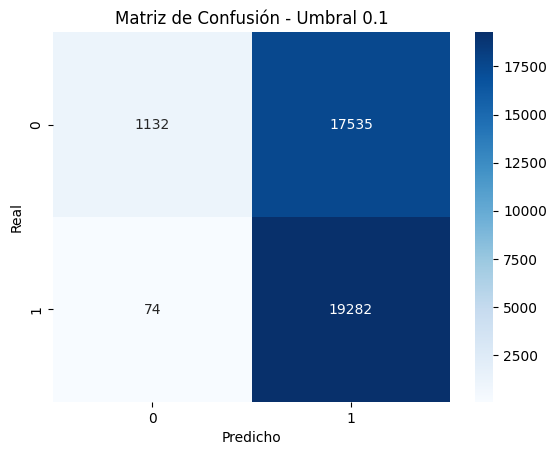

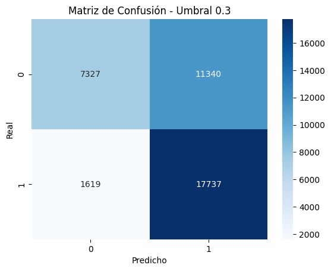

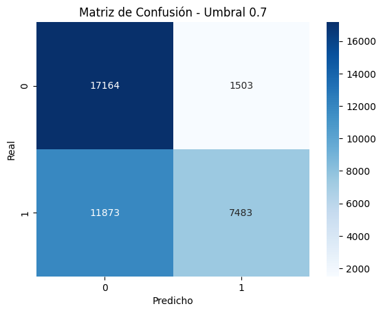

```python
# Análisis de umbrales
print("\n=== Análisis de umbrales ===")
for umbral in [0.1, 0.2, 0.3, 0.4, 0.5, 0.6, 0.7]:
    y_pred_u = (y_prob >= umbral).astype(int)
    print(f"\nUmbral {umbral}:")
    print(classification_report(y_test, y_pred_u, digits=3))

    import numpy as np
import seaborn as sns
import matplotlib.pyplot as plt
from sklearn.metrics import confusion_matrix

# Probabilidades
y_prob = logreg.predict_proba(x_test_scaled)[:, 1]

# Umbrales a comparar
thresholds = [0.1, 0.3, 0.7]

for t in thresholds:
    y_pred_thresh = (y_prob >= t).astype(int)
    cm = confusion_matrix(y_test, y_pred_thresh)

    plt.figure()
    sns.heatmap(cm, annot=True, fmt='d', cmap='Blues')
    plt.title(f'Matriz de Confusión - Umbral {t}')
    plt.xlabel('Predicho')
    plt.ylabel('Real')
    plt.show()
```

### Curva ROC y AUC

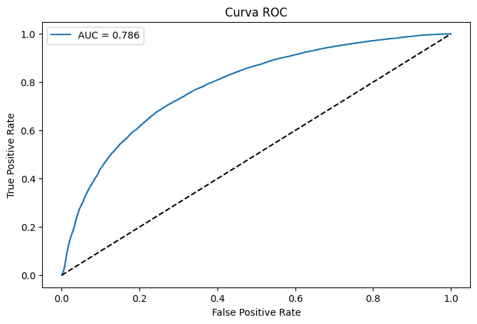

```python
from sklearn.metrics import roc_curve, roc_auc_score, f1_score, precision_score, recall_score

# Curva ROC
y_prob = logreg.predict_proba(x_test_scaled)[:, 1]
fpr, tpr, thresholds = roc_curve(y_test, y_prob)
auc = roc_auc_score(y_test, y_prob)

plt.figure(figsize=(8, 5))
plt.plot(fpr, tpr, label=f'AUC = {auc:.3f}')
plt.plot([0,1], [0,1], 'k--')
plt.xlabel('False Positive Rate')
plt.ylabel('True Positive Rate')
plt.title('Curva ROC')
plt.legend()
plt.show()
```

### Interpretación del modelo

Los coeficientes del modelo indican la dirección del efecto de cada variable sobre la probabilidad de tener seguro social, mientras que los odds ratios expresan ese efecto en términos más intuitivos de analizar. A continuación se despliegan los odds ratio de cada variable.

```python
import numpy as np

odds_ratios = np.exp(result.params)
conf_int = np.exp(result.conf_int())

odds_table = pd.DataFrame({
    "Odds Ratio": odds_ratios
})

print(odds_table)
```

```
                 Odds Ratio
const              1.086425
numren             0.892199
edad               1.234454
sexo               0.921513
educacion_total    1.649736
alfabetism         0.870240
hijos_viv          0.772334
parentesco         1.032298
diabetes           1.139159
pres_alta          1.192301
Discapacidad       0.979920
pop_insabi         0.773040
entidad            0.845863
conyug_3           1.089331
conyug_4           1.106819
conyug_6           0.881938
asis_esc           0.767951
trabajo_mp         1.306671
ingreso_total      2.001681
```

En conclusión, el análisis no solo permitió construir un modelo estadísticamente sólido, sino también comprender cómo variables socioeconómicas influyen en el acceso al seguro social. Esto refuerza la importancia de políticas públicas orientadas a mejorar la educación, fortalecer el empleo formal y reducir las brechas estructurales que limitan el acceso a mecanismos de garantización al seguro social.

## Referencias

TinaGongting. (2019, marzo 29). Understanding ROC AUC: Pros and cons. Why is Bier Score a Great Supplement? Medium. https://medium.com/@penggongting/understanding-roc-auc-pros-and-cons-why-is-bier-score-a-great-supplement-c7a0c976b679

How to explain the ROC AUC score and ROC curve? (s/f). Evidentlyai.com. Recuperado el 2 de marzo de 2026, de https://www.evidentlyai.com/classification-metrics/explain-roc-curve

**Utilizado para código de limpieza, merge y creación de gráficas**

OpenAI. (2023). ChatGPT (versión 2026). https://chat.openai.com/chat

Claude. (2026). Chatbot. https://chat.openai.com/chat

[output not shown]